# Food Demand Forecasting

This is a hackathon hosted by Analytics Vidya.

## Problem Statement:

Your client is a meal delivery company which operates in multiple cities. They have various fulfillment centers in these cities for dispatching meal orders to their customers. The client wants you to help these centers with demand forecasting for upcoming weeks so that these centers will plan the stock of raw materials accordingly.

The replenishment of majority of raw materials is done on weekly basis and since the raw material is perishable, the procurement planning is of utmost importance. Secondly, staffing of the centers is also one area wherein accurate demand forecasts are really helpful. Given the following information, the task is to predict the demand for the next 10 weeks (Weeks: 146-155) for the center-meal combinations in the test set:

1. Historical data of demand for a product-center combination (Weeks: 1 to 145)
2. Product(Meal) features such as category, sub-category, current price and discount
3. Information for fulfillment center like center area, city information etc.

We will start with looking at the data.

```r
suppressWarnings(library(dplyr))
suppressWarnings(library(data.table))
suppressWarnings(library(stats))
suppressWarnings(library(forecast))
suppressWarnings(library(tseries))
suppressWarnings(library(MLmetrics))
suppressWarnings(library(prophet))
suppressWarnings(library(bsts))
```

```r
suppressWarnings(library(ggplot2))


setwd("C:\\Data Science Projects\\Analytics Vidhya\\Food Demand Forecasting")

train = fread("train.csv")
center_info = fread("fulfilment_center_info.csv")
meal_info = fread("meal_info.csv")
test = fread("test_QoiMO9B.csv")
```

```r
head(train)
```

```
##         id week center_id meal_id checkout_price base_price
## 1: 1379560    1        55    1885         136.83     152.29
## 2: 1466964    1        55    1993         136.83     135.83
## 3: 1346989    1        55    2539         134.86     135.86
## 4: 1338232    1        55    2139         339.50     437.53
## 5: 1448490    1        55    2631         243.50     242.50
## 6: 1270037    1        55    1248         251.23     252.23
##    emailer_for_promotion homepage_featured num_orders
## 1:                     0                 0        177
## 2:                     0                 0        270
## 3:                     0                 0        189
## 4:                     0                 0         54
## 5:                     0                 0         40
## 6:                     0                 0         28
```

We have 9 columns. we have center_id corresponding to different centers of the delivery company and meal_id indicating the meal/Food Item that is being sold. Our aim is to predict the sales for each of these food items in every center.

num_orders seems to be the dependent variable that we need to predict. We also have 4 features along with this which we could define as- checkout price - price during checkout after offer is provided base price - price when there is no offers running emailer for promotion - customers targeted with email promoting a particular food item homepage featured - whether the food item was featured in the company’s website in that week

We also do not have the exact dates, but week numbers (cant expect much information from a hackathon). Our goal is to predict 10 weeks into the future.

We can derive certain metrics from the features. We can use the difference in the base price and checkout price as a feature instead of using both.

```r
train$diff_price <- train$base_price - train$checkout_price
test$diff_price <- test$base_price - test$checkout_price
center_id_list = sort(unique(test$center_id))
meal_id_list = sort(unique(test$meal_id))

train_week = unique(train$week)
test_week = unique(test$week)
```

We can have a holdout period equal to prediction horizon which is 10 weeks

```r
holdout_period = 10
prediction_horizon = 10
```

```r
print(length(center_id_list))
```

```
## [1] 77
```

```r
print(length(meal_id_list))
```

```
## [1] 51
```

We have 77 center IDs and 51 meal IDs. Let’s look at a sample and plot it

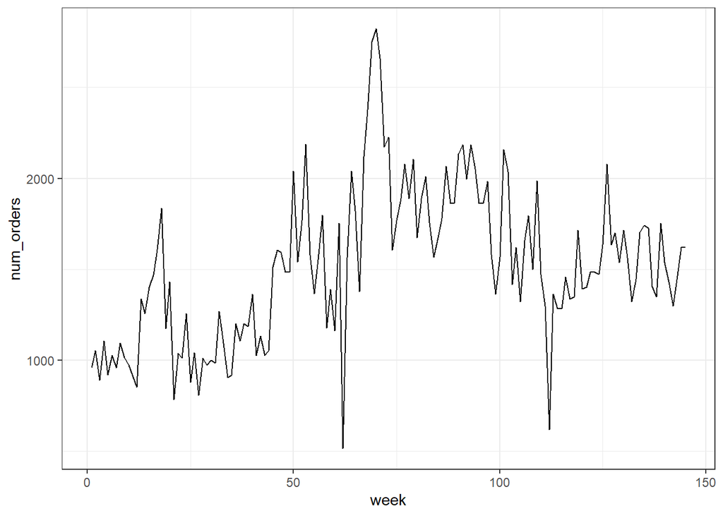

```r
center_id_i = 11
meal_id_j = 1885
sub_df <- train[train$center_id==center_id_i & train$meal_id==meal_id_j]
ggplot(sub_df[,c("week", "num_orders")], aes(x = week, y = num_orders)) + geom_line() + theme_bw()
```

There seems to be some trend from the first year to second year. However the trend is not present moving from 2nd year to third. There seems to be seasonality in the period that we are going to predict. Lets check these facts using R.

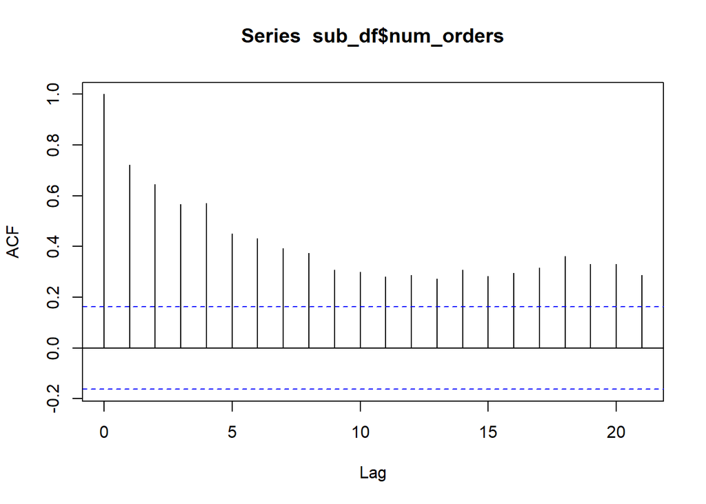

```r
acf(sub_df$num_orders)
```

There seems to be some autocorrelation between the lags.

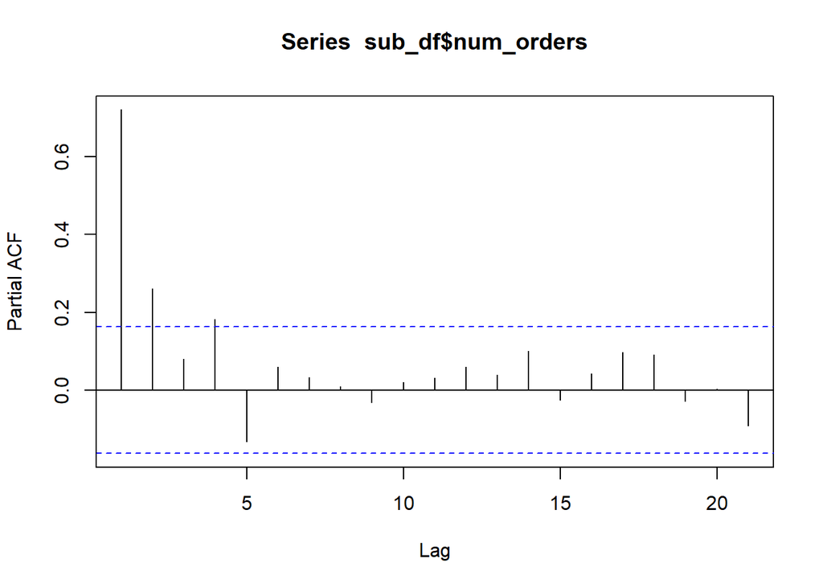

```r
pacf(sub_df$num_orders)
```

PACF cuts off at lag 2 which indicates that the residuals can have some information in the prediction.

It is good to visualize these trends but auto.arima will take care of this.

Lets see how the features are correlated.

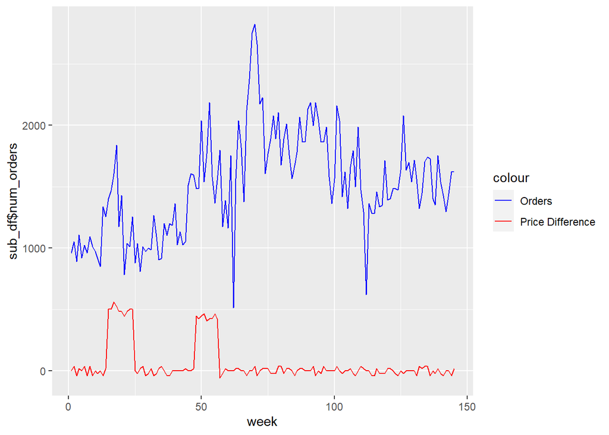

```r
p = ggplot(sub_df[,c("week", "num_orders", "diff_price")], aes(x = week))
p = p + geom_line(aes(y = sub_df$num_orders, color = "Orders"))
p = p + geom_line(aes(y = sub_df$diff_price*20, color = "Price Difference"))
p = p + scale_colour_manual(values = c("blue", "red"))
plot(p)
```

From the plot, we can visually see that when there is a difference in Base price and checkout price, we have higher number of orders. This makes sense as people would buy an item when there is a discount. This regressor should add a lot of value to our model.

I have used 3 methods to forecast here - Arima, Prophet and BSTS. We will be identifying the best model for each center ID, meal ID combination using MAPE (Mean Absolute Percentage Error).

```r
# Functions

# Treat Dataframe
treat_sub_df <- function(sub_df){
  if(nrow(sub_df) <= 100){
    return(sub_df)
  }

  treated_sub_df <- data.frame(week=seq(from=1, to=145, by=1))
  treated_sub_df <- merge(treated_sub_df, sub_df, by="week", all.x=TRUE)
  treated_sub_df$center_id <- unique(sub_df$center_id)
  treated_sub_df$meal_id <- unique(sub_df$meal_id)
  treated_sub_df$homepage_featured <- ifelse(is.na(treated_sub_df$homepage_featured), 0, treated_sub_df$homepage_featured)
  treated_sub_df$emailer_for_promotion <- ifelse(is.na(treated_sub_df$emailer_for_promotion), 0, treated_sub_df$emailer_for_promotion)
  treated_sub_df$diff_price <- ifelse(is.na(treated_sub_df$diff_price), 0, treated_sub_df$diff_price)

  prev_num_order <- 0
  for(i in treated_sub_df$week){
    if(is.na(treated_sub_df[treated_sub_df$week==i,]$num_orders)){
      treated_sub_df[treated_sub_df$week==i,]$num_orders <- prev_num_order
    } else {
      prev_num_order <- treated_sub_df[treated_sub_df$week==i,]$num_orders
    }

  }
  return(treated_sub_df)
}
# ARIMA
model_arima <- function(sub_df2, test_df, prediction_horizon){

  sub_ts <- ts(sub_df2$num_orders, frequency=52)
  xreg_train <- as.matrix(sub_df2[,c("diff_price", "homepage_featured")])

  xreg_test_df <- data.frame(week = seq(from=146, to=155, by=1))
  xreg_test_df <- merge(xreg_test_df, test_df[,c("week", "homepage_featured", "diff_price")], by='week', all.x=TRUE)
  xreg_test_df$homepage_featured <- ifelse(is.na(xreg_test_df$homepage_featured), 0, xreg_test_df$homepage_featured)
  xreg_test_df$diff_price <- ifelse(is.na(xreg_test_df$diff_price), 0, xreg_test_df$diff_price)
  xreg_test <- as.matrix(xreg_test_df[,c("diff_price", "homepage_featured")])
  if(nrow(sub_df2) >= 104){
    arima <- auto.arima(sub_ts, xreg=xreg_train, seasonal=TRUE)
  } else{
    arima <- auto.arima(sub_ts, xreg=xreg_train, seasonal=FALSE)
  }
  forecast_arima <- forecast(arima, h=prediction_horizon, xreg=xreg_test)
  #print(forecast_arima$mean)
  forecast_df <- data.frame(forecast_val=as.numeric(forecast_arima$mean))
  return(forecast_df)
}


# PROPHET
model_prophet <- function(sub_df2, test_df){
  #ts_df <- sub_ts
  # xreg <- xreg_train

  ds <- seq(as.Date('2017-01-01'), by ="w", length=nrow(sub_df2))
  df <- data.frame(ds=ds, y=sub_df2$num_orders)
  m <- prophet(weekly.seasonality = TRUE, daily.seasonality = FALSE)
  x_reg_diff_price <- data.frame(ds=ds, x_reg_diff_price = as.matrix(sub_df2$diff_price))
  x_reg_hf <- data.frame(ds=ds, x_reg_hf = as.matrix(sub_df2$homepage_featured))
  m <- add_regressor(m, "x_reg_diff_price", standardize = FALSE)
  m <- add_regressor(m, "x_reg_hf", standardize = FALSE)

  ds2 <- merge(df, x_reg_diff_price, by='ds', all.x=TRUE)
  ds2 <- merge(ds2, x_reg_hf, by='ds', all.x=TRUE)
  ds2$x_reg_diff_price <- ifelse(is.na(ds2$x_reg_diff_price), 0, ds2$x_reg_diff_price)
  ds2$x_reg_hf <- ifelse(is.na(ds2$x_reg_hf), 0, ds2$x_reg_hf)
  #setnames(ds, "xreg_train", "x_mat1")
  m <- fit.prophet(m, ds2)
  future <- make_future_dataframe(m, period=holdout_period, freq='week', include_history = FALSE)
  #future <- merge(future, x_mat1, by='ds', all.x=TRUE)


  xreg_test_df <- data.frame(week = sort(unique(test$week)))
  xreg_test_df$ds <- seq(as.Date("2019-10-13"), by="w", length=nrow(xreg_test_df))
  xreg_test_df <- merge(xreg_test_df, test_df[,c("week", "diff_price", "homepage_featured")], by="week", all.x=TRUE)
  xreg_test_df$diff_price <- ifelse(is.na(xreg_test_df$diff_price), 0, xreg_test_df$diff_price)
  xreg_test_df$homepage_featured <- ifelse(is.na(xreg_test_df$homepage_featured), 0, xreg_test_df$homepage_featured)

  future$x_reg_diff_price <- xreg_test_df$diff_price
  future$x_reg_hf <- xreg_test_df$homepage_featured
  forecast_prophet <- predict(m, future)
  forecast_df <- data.frame(forecast_val=as.numeric(forecast_prophet$yhat))
  return(forecast_df)
}



# BSTS
model_bsts <- function(sub_df2, test_df){

  xreg_test_df <- data.frame(week = sort(unique(test$week)))
  xreg_test_df$ds <- seq(as.Date("2019-10-13"), by="w", length=nrow(xreg_test_df))
  xreg_test_df <- merge(xreg_test_df, test_df[,c("week", "diff_price", "homepage_featured")], by="week", all.x=TRUE)
  xreg_test_df$diff_price <- ifelse(is.na(xreg_test_df$diff_price), 0, xreg_test_df$diff_price)
  xreg_test_df$homepage_featured <- ifelse(is.na(xreg_test_df$homepage_featured), 0, xreg_test_df$homepage_featured)

  sub_df2$diff_price <- abs(sub_df2$diff_price)
  xreg_test_df$diff_price <- abs(xreg_test_df$diff_price)

  y <- sub_df2$num_orders
  #y <- log10(y)
  ss <- list()
  ss <- AddSemilocalLinearTrend(list(), y)
  #ss <- AddAr(ss, y)
  ss <- AddSeasonal(ss, y, nseasons=52)
  ss <- AddDynamicRegression(ss, y~as.matrix(sub_df2[,c("diff_price", "homepage_featured")]))
  bsts.model <- bsts(y, state.specification = ss, niter=500, ping=0, seed=2020)
  burn <- SuggestBurn(0.1, bsts.model)

  p <- predict.bsts(bsts.model,
                    horizon=prediction_horizon,
                    burn=burn,
                    quantiles=c(0.025, 0.975),
                    newdata = as.matrix(xreg_test_df[,c("diff_price", "homepage_featured")]))

  forecast_df <- data.frame(forecast_val=as.numeric(p$mean))
  return(forecast_df)
}


# Using MAPE to identify the best model
find_best_model <- function(sub_df_t, holdout_period){

  sub_df_1 <- sub_df_t[1:(nrow(sub_df_t)-holdout_period),]
  sub_df_hold <- sub_df_t[(nrow(sub_df_t)-holdout_period+1):nrow(sub_df_t),]
  mape_df <- data.frame(actual = sub_df_hold$num_orders)

  # Arima
  tryCatch({
    arima <- auto.arima(sub_df_1$num_orders,seasonal=TRUE, xreg= as.matrix(sub_df_1[,c("diff_price", "homepage_featured")]))
    holdout_forecast <- forecast(arima, h=holdout_period, xreg=as.matrix(sub_df_hold[,c("diff_price", "homepage_featured")]))
    mape_df$arima <- holdout_forecast$mean
  }, error = function(e){
  })

  # Prophet
  tryCatch({
    ds <- seq(as.Date('2017-01-01'), by ="w", length=nrow(sub_df_1))
    df <- data.frame(ds=ds, y=sub_df_1$num_orders)
    m <- prophet(weekly.seasonality = TRUE, daily.seasonality = FALSE)
    x_reg_diff_price <- data.frame(ds=ds, x_reg_diff_price = as.matrix(sub_df_1[,c("diff_price")]))
    x_reg_hf <- data.frame(ds=ds, x_reg_hf = as.matrix(sub_df_1[,c("homepage_featured")]))
    m <- add_regressor(m, "x_reg_diff_price", standardize = FALSE)
    m <- add_regressor(m, "x_reg_hf", standardize = FALSE)
    ds2 <- merge(df, x_reg_diff_price, by='ds', all.x=TRUE)
    ds2 <- merge(ds2, x_reg_hf, by='ds', all.x=TRUE)
    ds2[is.na(ds2$x_reg_diff_price)]$x_reg_diff_price <- 0
    ds2[is.na(ds2$x_reg_hf)]$x_reg_hf <- 0
    #setnames(ds2, "xreg_train", "x_mat1")
    m <- fit.prophet(m, ds2)
    future <- make_future_dataframe(m, period=holdout_period, freq='week', include_history = FALSE)
    #future <- merge(future, x_mat1, by='ds', all.x=TRUE)
    names(future)
    future$x_reg_diff_price <- sub_df_hold$diff_price
    future$x_reg_hf <- sub_df_hold$homepage_featured

    holdout_forecast_p <- predict(m, future)
    mape_df$prophet <- holdout_forecast_p$yhat
  }, error = function(e){
  })

  # BSTS
  tryCatch({
    sub_df_hold$diff_price <- abs(sub_df_hold$diff_price)
    sub_df_1$diff_price <- abs(sub_df_1$diff_price)
    y <- sub_df_1$num_orders
    #y <- log10(y)
    ss <- list()
    ss <- AddSemilocalLinearTrend(list(), y)
    #ss <- AddAr(ss, y)
    ss <- AddSeasonal(ss, y, nseasons=52)
    ss <- AddDynamicRegression(ss, y~as.matrix(sub_df_1[,c("diff_price", "homepage_featured")]))
    bsts.model <- bsts(y, state.specification = ss, niter=500, ping=0, seed=2020)
    burn <- SuggestBurn(0.1, bsts.model)

    p <- predict.bsts(bsts.model,
                      horizon=holdout_period,
                      burn=burn,
                      quantiles=c(0.025, 0.975),
                      newdata = as.matrix(sub_df_hold[,c("diff_price", "homepage_featured")]))
    mape_df$bsts <- p$mean
  }, error = function(e){
  })

  mape_df2 <- data.frame(
    model = as.character(),
    mape = as.double()
  )


  mape_df2 = rbind(mape_df2, data.frame(model = "Arima", mape = MAPE(mape_df$arima, mape_df$actual)))
  mape_df2 = rbind(mape_df2, data.frame(model = "Prophet",mape = MAPE(mape_df$prophet, mape_df$actual)))
  mape_df2 = rbind(mape_df2, data.frame(model = "BSTS",mape = MAPE(mape_df$bsts, mape_df$actual)))
  mape_df2 <- mape_df2[order(mape_df2$mape),]
  return(mape_df2)
}
```

```r
output_df <- data.frame(
  center_id=int(),
  meal_id=int(),
  week=int(),
  forecast_val=double()
)



# execute model
stopper = 0
stop_a = 1
for (center_id_i in center_id_list){
  if (stopper >= stop_a){ break}  # This is just for testing/breaking the loop when needed
  for (meal_id_j in meal_id_list){
    print(c('Center:', center_id_i))
    print(c('Meal:', meal_id_j))
    #if (stopper >= stop_a){ break}
    if (stopper %%100==0){print(stopper)}

    sub_df <- train[train$center_id==center_id_i & train$meal_id==meal_id_j]
    if (nrow(sub_df) <= 10){next}
    sub_df_t <- treat_sub_df(sub_df)   # Treating the data

    mape_df2 <- find_best_model(sub_df_t, holdout_period)   # finding the best model
    mape_df3 <- mape_df2[1,]  # considering the best model based on MAPE

    print(mape_df3$model)


    test_df <- test[test$center_id==center_id_i & test$meal_id==meal_id_j]
    if (nrow(sub_df) <= 10){next}
    sub_df2 <- data.frame(week = train_week)
    sub_df2 <- merge(sub_df2, sub_df_t[,c("week", "num_orders", "diff_price", "homepage_featured")], by="week", all.x=TRUE)
    sub_df2[is.na(sub_df2)] = 0

    model_flag = 0
    if(mape_df3$model=='Arima'){
      tryCatch({
      forecast_df <- model_arima(sub_df2, test_df, prediction_horizon)
      }, error = function(e){
      })
    } else if(mape_df3$model == 'Prophet'){
      forecast_df <- model_prophet(sub_df2, test_df)
    } else if(mape_df3$model == 'BSTS'){
      forecast_df <- model_bsts(sub_df2, test_df)
    }

    #forecast_df <- model_arima(sub_df2, test_df, prediction_horizon)
    forecast_df$center_id <- center_id_i
    forecast_df$meal_id <- meal_id_j
    forecast_df$week <- test_week

    output_df <- rbind(output_df, forecast_df[,c(2,3,4,1)])
    stopper = stopper + 1

    break # breaking here for a sample
  }
}
```

```
## [1] "Center:" "10"
## [1] "Meal:" "1062"
## [1] 0
## [1] "Arima"
```

```r
test_out <- merge(x=test, y=output_df, by=c("meal_id", "center_id", "week"), all.x=TRUE)
# submission file
setnames(test_out, "forecast_val", "num_orders")
test_out$num_orders[is.na(test_out$num_orders)] <- 0
test_out$num_orders[test_out$num_orders<=0] <- 0
submission_df <- test_out[,c("id", "num_orders")]
write.csv(submission_df, "submission2.csv", row.names=FALSE)
```

I have tried various iterations and got a RMSLE score of 69.9. The top RMSLE score was 47.7.

We could try more, but the main aim of this excercise was to learn the intricacies of each of these models. We can get a better score when we have a better and deeper understanding of the business.